# Week11

Vivian Kong

4/18/2018

```r
library(ggplot2)
data(cars)
head(cars)
```

```
##   speed dist
## 1     4    2
## 2     4   10
## 3     7    4
## 4     7   22
## 5     8   16
## 6     9   10
```

```r
summary(cars)
```

```
##      speed           dist
##  Min.   : 4.0   Min.   :  2.00
##  1st Qu.:12.0   1st Qu.: 26.00
##  Median :15.0   Median : 36.00
##  Mean   :15.4   Mean   : 42.98
##  3rd Qu.:19.0   3rd Qu.: 56.00
##  Max.   :25.0   Max.   :120.00
```

# Visualize the data

```r
carslm <- lm(cars$dist ~ cars$speed)
carslm
```

```
##
## Call:
## lm(formula = cars$dist ~ cars$speed)
##
## Coefficients:
## (Intercept)   cars$speed
##     -17.579        3.932
```

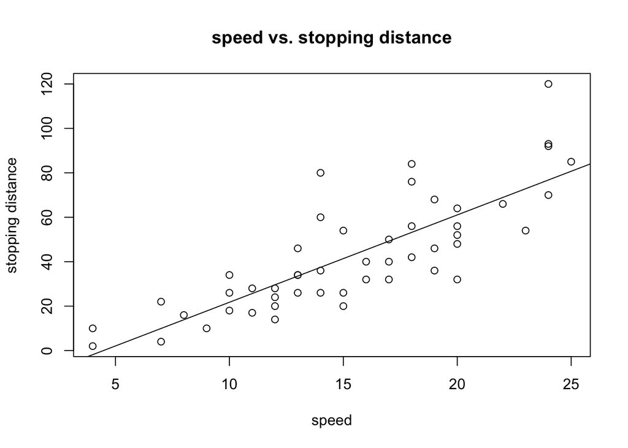

```r
plot(cars$speed,cars$dist, main ="speed vs. stopping distance", xlab="speed", ylab="stopping distance")
abline(carslm)
```

# Quality Evaluation

```r
summary(carslm)
```

```
##
## Call:
## lm(formula = cars$dist ~ cars$speed)
##
## Residuals:
##     Min      1Q  Median      3Q     Max
## -29.069  -9.525  -2.272   9.215  43.201
##
## Coefficients:
##             Estimate Std. Error t value Pr(>|t|)
## (Intercept) -17.5791     6.7584  -2.601   0.0123 *
## cars$speed    3.9324     0.4155   9.464 1.49e-12 ***
## ---
## Signif. codes:  0 '***' 0.001 '**' 0.01 '*' 0.05 '.' 0.1 ' ' 1
##
## Residual standard error: 15.38 on 48 degrees of freedom
## Multiple R-squared:  0.6511, Adjusted R-squared:  0.6438
## F-statistic: 89.57 on 1 and 48 DF,  p-value: 1.49e-12
```

##According to the textbook, we know that if the line is a good fit with the data, the median value of residual is near zero, min and max values of roughly the same magnitude. For this model, the median is -2.272 which is preety close to 0, min and max is similar magnitude. Also, for a good linear model, standard error for each coefficients that is at least 5 to 10 times smaller than the corresponding coefficent. For the standard error for speed is (3.9324/0.4155=9.4642) This ratio fits the category we are talking about. For the p-value of the coefficient is 1.49e-12, a tiny value - the probability is not relevant in this model. It indicates the model fits pretty well.

# Residual Analysis

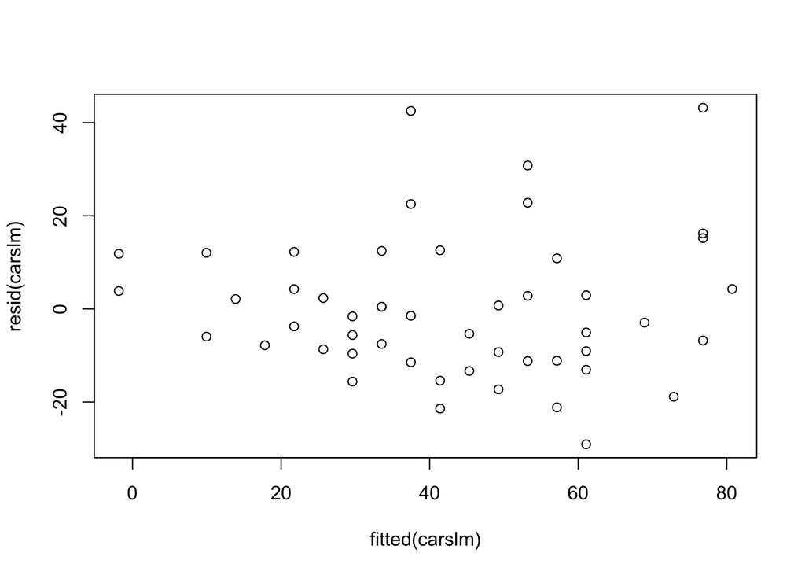

```r
plot(fitted(carslm),resid(carslm))
```

##In this plot, we see the residuals roughly cluster around 0 which indicates the model is relatively good fit.

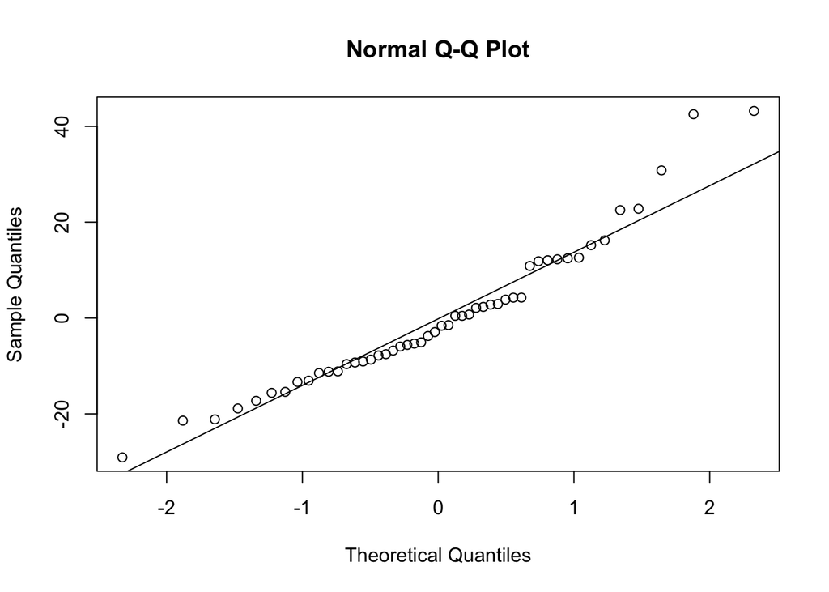

```r
qqnorm(resid(carslm))
qqline(resid(carslm))
```

##We know that if the residuals were normally distributed, we would expect the points follow a straight line. In our model, we can see that most points follow the straight line. It also indicates that the linear model is reliable.